# Assignment 4

Victor Torres

2025-05-10

# Final Project

## Sections

### Choose a dataset

You get to decide which dataset you want to work on. The data set must be different from the ones used in previous homeworks You can work on a problem from your job, or something you are interested in. You may also obtain a dataset from sites such as Kaggle, Data.Gov, Census Bureau, USGS or other open data portals.

##### For this assignment, I decided to use a “Telco Customer Churn” dataset that I found in Kaggle. This data is about a fictional telco company that provided home phone and Internet services to 7043 customers in California in Q3. It indicates which customers have left, stayed, or signed up for their service. Multiple important demographics are included for each customer, as well as a Satisfaction Score, Churn Score, and Customer Lifetime Value (CLTV) index.

```r
# Load dataset
teldata <- read.csv("C:/Users/vitug/OneDrive/Desktop/CUNY Masters/DATA_622/telco.csv", stringsAsFactors = FALSE)
# Review data structure
str(teldata)
```

```
## 'data.frame':    7043 obs. of  50 variables:
##  $ Customer.ID                      : chr  "8779-QRDMV" "7495-OOKFY" "1658-BYGOY" "4598-XLKNJ" ...
##  $ Gender                           : chr  "Male" "Female" "Male" "Female" ...
##  $ Age                              : int  78 74 71 78 80 72 76 66 70 77 ...
##  $ Under.30                         : chr  "No" "No" "No" "No" ...
##  $ Senior.Citizen                   : chr  "Yes" "Yes" "Yes" "Yes" ...
##  $ Married                          : chr  "No" "Yes" "No" "Yes" ...
##  $ Dependents                       : chr  "No" "Yes" "Yes" "Yes" ...
##  $ Number.of.Dependents             : int  0 1 3 1 1 1 2 0 2 2 ...
##  $ Country                          : chr  "United States" "United States" "United States" "United States" ...
##  $ State                            : chr  "California" "California" "California" "California" ...
##  $ City                             : chr  "Los Angeles" "Los Angeles" "Los Angeles" "Inglewood" ...
##  $ Zip.Code                         : int  90022 90063 90065 90303 90602 90660 90720 91024 91106 91107 ...
##  $ Latitude                         : num  34 34 34.1 33.9 34 ...
##  $ Longitude                        : num  -118 -118 -118 -118 -118 ...
```

[output cut: 36 more lines]

```r
# Data Summary
summary(teldata)
```

```
##  Customer.ID           Gender               Age          Under.30
##  Length:7043        Length:7043        Min.   :19.00   Length:7043
##  Class :character   Class :character   1st Qu.:32.00   Class :character
##  Mode  :character   Mode  :character   Median :46.00   Mode  :character
##                                        Mean   :46.51
##                                        3rd Qu.:60.00
##                                        Max.   :80.00
##  Senior.Citizen       Married           Dependents        Number.of.Dependents
##  Length:7043        Length:7043        Length:7043        Min.   :0.0000
##  Class :character   Class :character   Class :character   1st Qu.:0.0000
##  Mode  :character   Mode  :character   Mode  :character   Median :0.0000
##                                                           Mean   :0.4687
##                                                           3rd Qu.:0.0000
##                                                           Max.   :9.0000
##    Country             State               City              Zip.Code
##  Length:7043        Length:7043        Length:7043        Min.   :90001
##  Class :character   Class :character   Class :character   1st Qu.:92101
##  Mode  :character   Mode  :character   Mode  :character   Median :93518
##                                                           Mean   :93486
##                                                           3rd Qu.:95329
##                                                           Max.   :96150
##     Latitude       Longitude        Population       Quarter
##  Min.   :32.56   Min.   :-124.3   Min.   :    11   Length:7043
##  1st Qu.:33.99   1st Qu.:-121.8   1st Qu.:  2344   Class :character
##  Median :36.21   Median :-119.6   Median : 17554   Mode  :character
##  Mean   :36.20   Mean   :-119.8   Mean   : 22140
##  3rd Qu.:38.16   3rd Qu.:-118.0   3rd Qu.: 36125
##  Max.   :41.96   Max.   :-114.2   Max.   :105285
##  Referred.a.Friend  Number.of.Referrals Tenure.in.Months    Offer
##  Length:7043        Min.   : 0.000      Min.   : 1.00    Length:7043
##  Class :character   1st Qu.: 0.000      1st Qu.: 9.00    Class :character
##  Mode  :character   Median : 0.000      Median :29.00    Mode  :character
##                     Mean   : 1.952      Mean   :32.39
##                     3rd Qu.: 3.000      3rd Qu.:55.00
##                     Max.   :11.000      Max.   :72.00
##  Phone.Service      Avg.Monthly.Long.Distance.Charges Multiple.Lines
##  Length:7043        Min.   : 0.00                     Length:7043
##  Class :character   1st Qu.: 9.21                     Class :character
##  Mode  :character   Median :22.89                     Mode  :character
##                     Mean   :22.96
```

[output cut: 43 more lines]

```
##  Max.   :3564.72             Max.   :11979.34   Max.   :5.000
##  Customer.Status    Churn.Label         Churn.Score         CLTV
##  Length:7043        Length:7043        Min.   : 5.00   Min.   :2003
##  Class :character   Class :character   1st Qu.:40.00   1st Qu.:3469
##  Mode  :character   Mode  :character   Median :61.00   Median :4527
##                                        Mean   :58.51   Mean   :4400
##                                        3rd Qu.:75.50   3rd Qu.:5380
##                                        Max.   :96.00   Max.   :6500
##  Churn.Category     Churn.Reason
##  Length:7043        Length:7043
##  Class :character   Class :character
##  Mode  :character   Mode  :character
##
##
##
```

```r
# Check for missing values
missing_values <- colSums(is.na(teldata))
print(missing_values[missing_values > 0])
```

```
## named numeric(0)
```

### Describe the problem you are trying to solve.

The main goal of this analysis is to find out the rate of customers that stops doing business with the company, find out what are the main factors and behaviors that might impact to this decision, such as “age”, “location”, “marital status”, “competitors offers”, “customer service satisfaction”, etc. This analysis is crucial for the company because it directly displays its overall business performance as well as the company revenue and losses.

### Describe your dataset and what you did to prepare the data for analysis.

After reviewing the dataset structure and summary, I can see that data frame contains information about 7,043 telecom customers with 50 variables covering various aspects of customer profiles and behaviors, some of the most important are:

- Demographic information: Age, gender, marital status, dependents, location.

- Account information: Tenure, contract type, payment method, billing preferences.

- Service usage: Phone service, internet service, add-on services Financial metrics: Monthly charges, total charges, CLTV (Customer Lifetime Value).

#### Data Preparation

Before proceeding to build the models, I am going to perform some data preparation, type conversion, feature engineering, and normalization to obtain more accurate results.

```r
# Convert categorical variables to factors
categorical_vars <- c("Gender", "Under.30", "Senior.Citizen", "Married",
                      "Dependents", "Country", "State", "City", "Quarter",
                      "Referred.a.Friend", "Offer", "Phone.Service",
                      "Multiple.Lines", "Internet.Service", "Internet.Type",
                      "Online.Security", "Online.Backup", "Device.Protection.Plan",
                      "Premium.Tech.Support", "Streaming.TV", "Streaming.Movies",
                      "Streaming.Music", "Unlimited.Data", "Contract",
                      "Paperless.Billing", "Payment.Method", "Customer.Status",
                      "Churn.Label", "Churn.Category", "Churn.Reason")

teldata[categorical_vars] <- lapply(teldata[categorical_vars], as.factor)

# Create binary churn variable
teldata$Churn.Binary <- ifelse(teldata$Churn.Label == "Yes", 1, 0)
```

#### EDA

Now that the data is prepared, I am going to analyze the distribution of the “churn” variable, as well as relationships between several variables with the ’churn” variable.

```r
# Basic distribution of churn
churn_distribution <- teldata %>%
  count(Churn.Label) %>%
  mutate(percentage = n / sum(n) * 100)
print(churn_distribution)
```

```
##   Churn.Label    n percentage
## 1          No 5174   73.46301
## 2         Yes 1869   26.53699
```

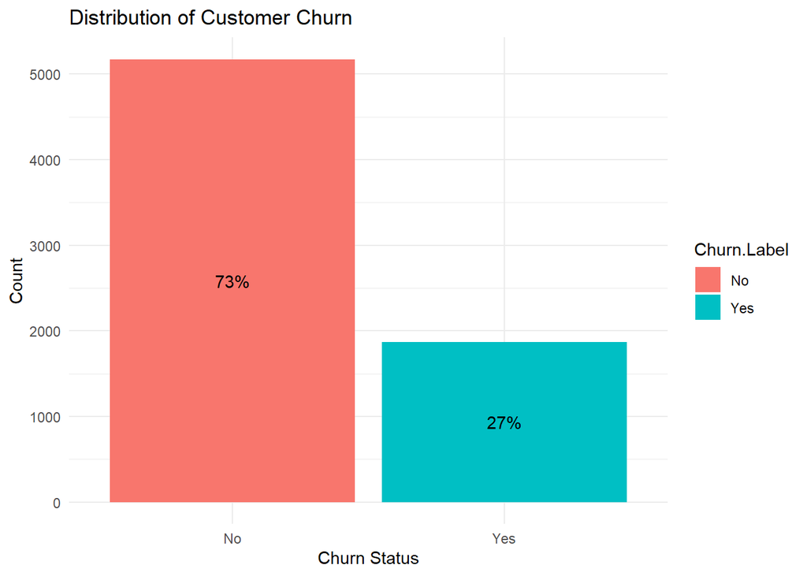

```r
# Visualize churn distribution
ggplot(teldata, aes(x = Churn.Label, fill = Churn.Label)) +
  geom_bar() +
  geom_text(stat = "count", aes(label = scales::percent(..count../sum(..count..))),
            position = position_stack(vjust = 0.5)) +
  labs(title = "Distribution of Customer Churn", x = "Churn Status", y = "Count") +
  theme_minimal()
```

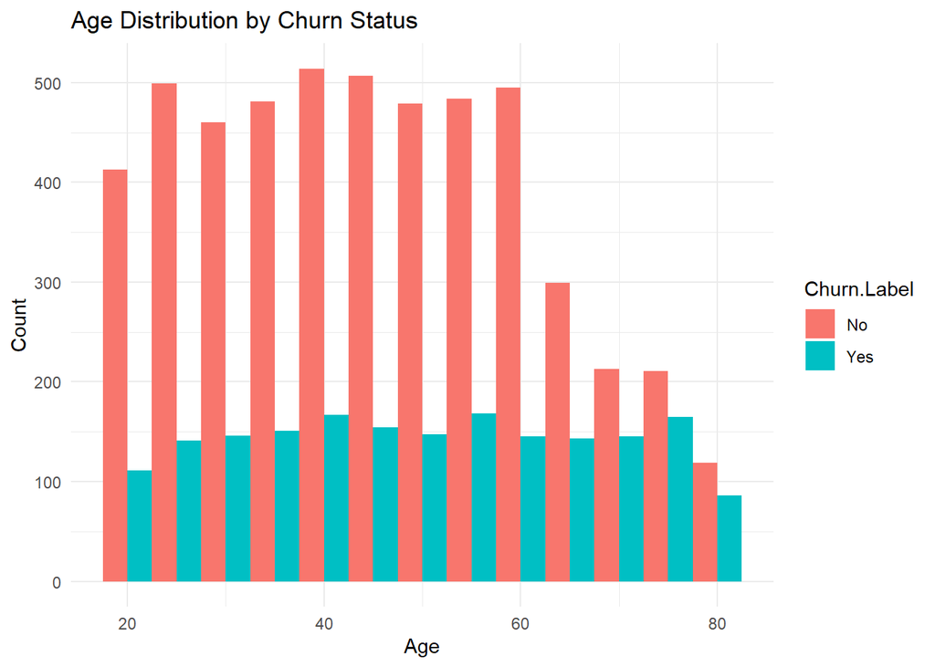

```r
# Exploring relationship between age and churn
ggplot(teldata, aes(x = Age, fill = Churn.Label)) +
  geom_histogram(binwidth = 5, position = "dodge") +
  labs(title = "Age Distribution by Churn Status", x = "Age", y = "Count") +
  theme_minimal()
```

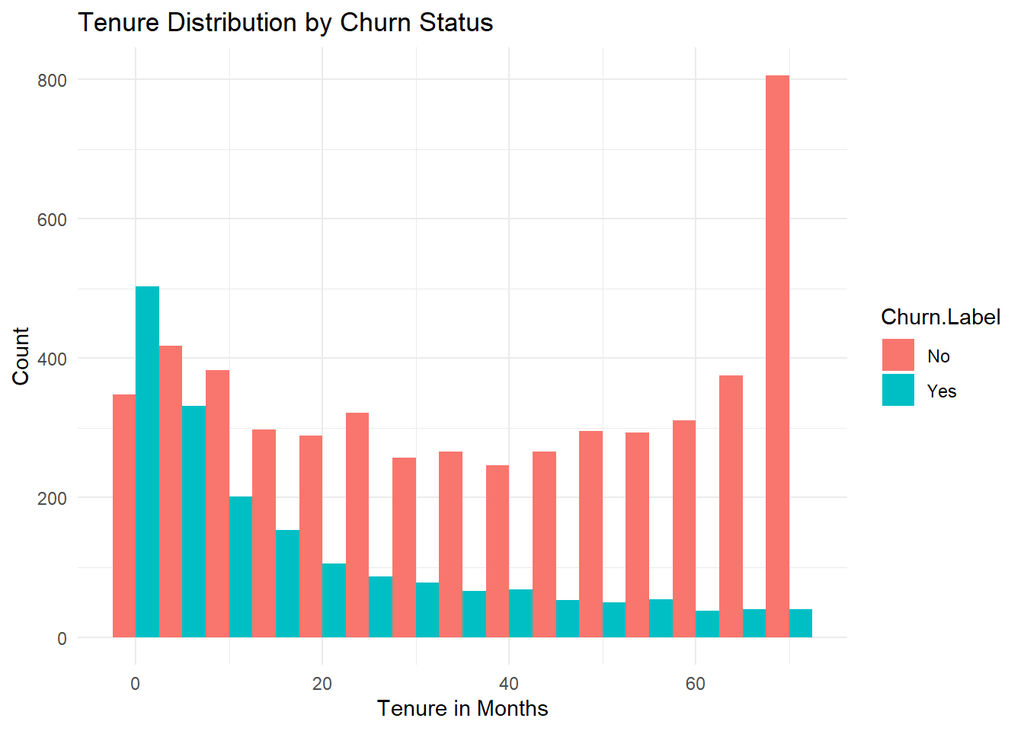

```r
# Exploring relationship between tenure and churn
ggplot(teldata, aes(x = Tenure.in.Months, fill = Churn.Label)) +
  geom_histogram(binwidth = 5, position = "dodge") +
  labs(title = "Tenure Distribution by Churn Status", x = "Tenure in Months", y = "Count") +
  theme_minimal()
```

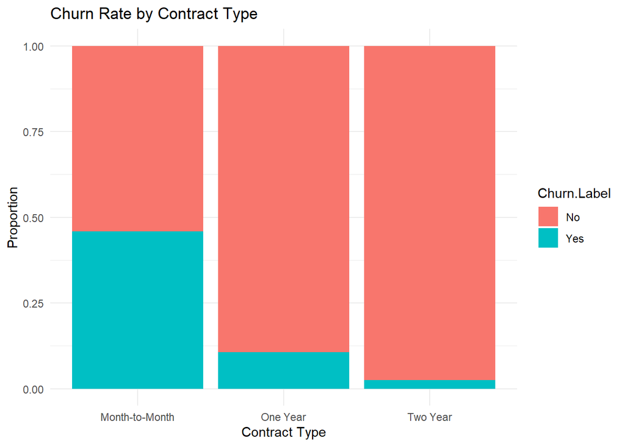

```r
# Contract type and churn
ggplot(teldata, aes(x = Contract, fill = Churn.Label)) +
  geom_bar(position = "fill") +
  labs(title = "Churn Rate by Contract Type", x = "Contract Type", y = "Proportion") +
  theme_minimal()
```

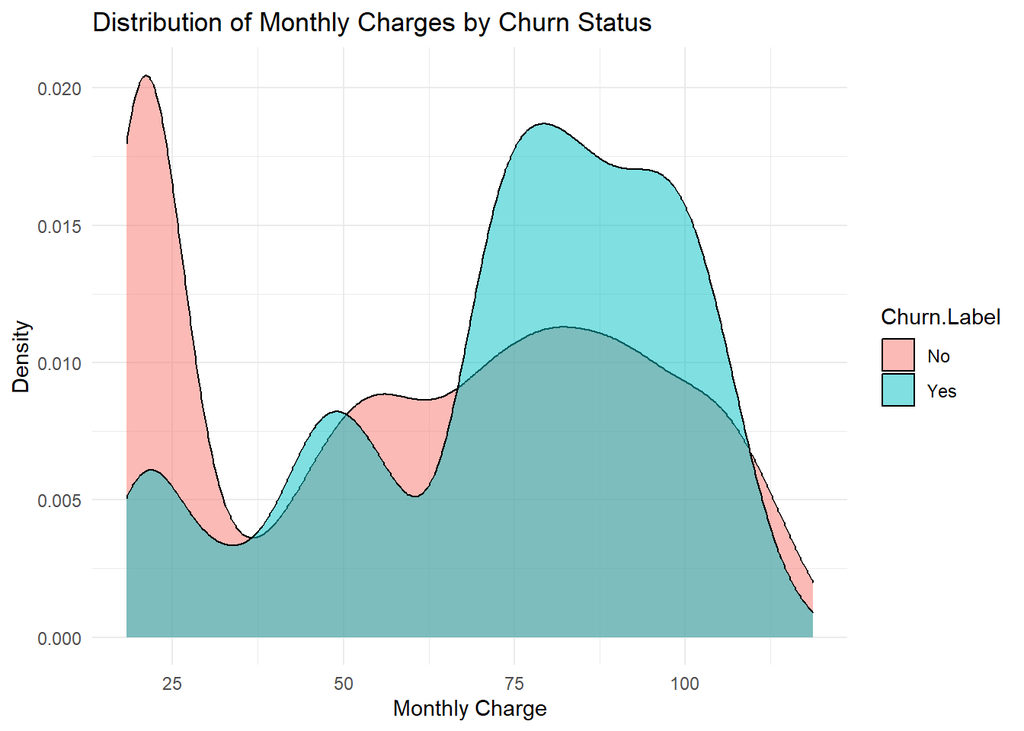

```r
# Monthly charges and churn
ggplot(teldata, aes(x = Monthly.Charge, fill = Churn.Label)) +
  geom_density(alpha = 0.5) +
  labs(title = "Distribution of Monthly Charges by Churn Status", x = "Monthly Charge", y = "Density") +
  theme_minimal()
```

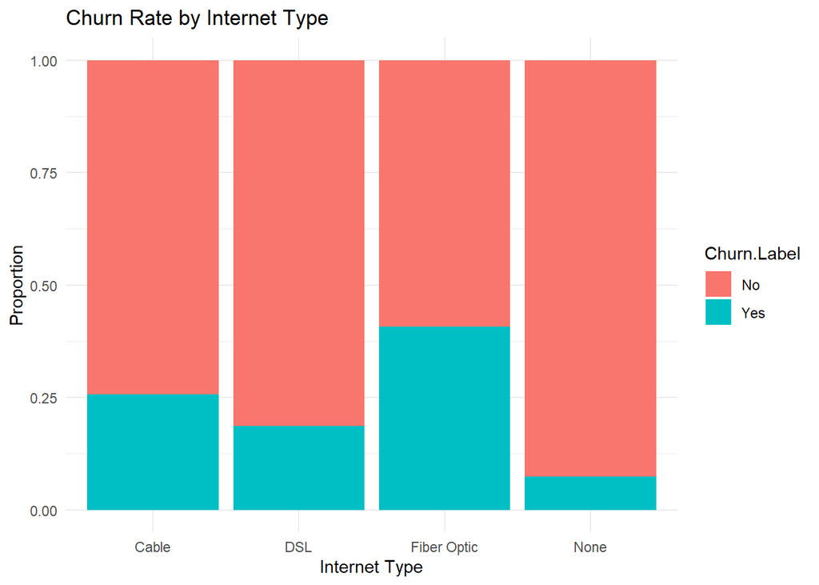

```r
# Internet type and churn
ggplot(teldata, aes(x = Internet.Type, fill = Churn.Label)) +
  geom_bar(position = "fill") +
  labs(title = "Churn Rate by Internet Type", x = "Internet Type", y = "Proportion") +
  theme_minimal()
```

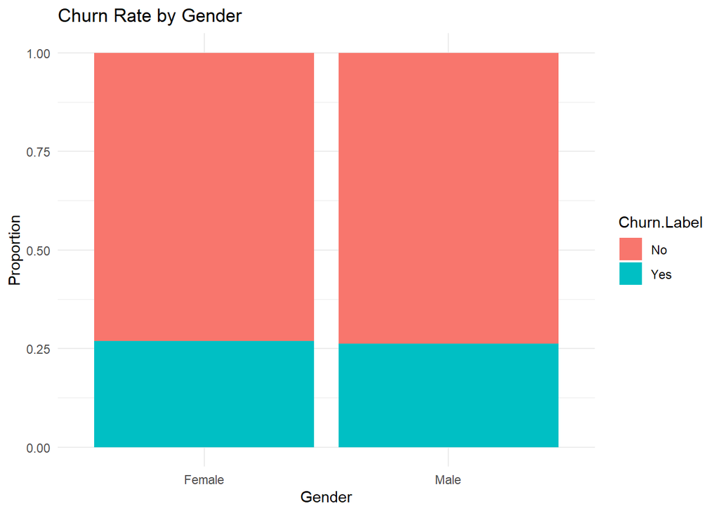

```r
# Gender and churn
ggplot(teldata, aes(x = Gender, fill = Churn.Label)) +
  geom_bar(position = "fill") +
  labs(title = "Churn Rate by Gender", x = "Gender", y = "Proportion") +
  theme_minimal()
```

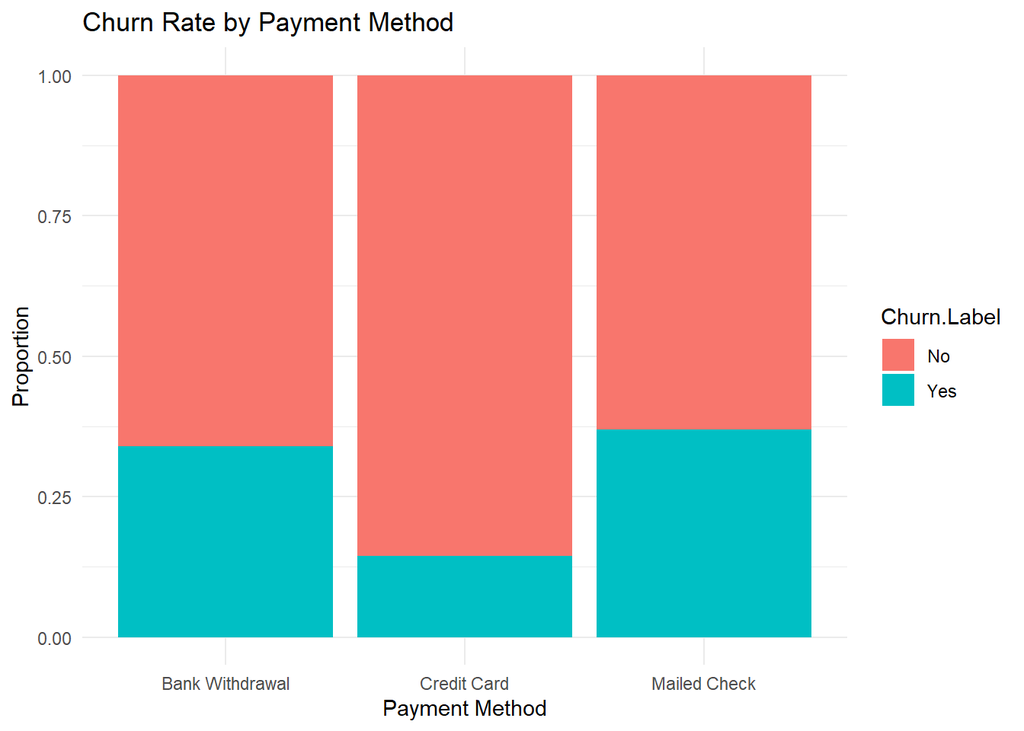

```r
# Payment method and churn
ggplot(teldata, aes(x = Payment.Method, fill = Churn.Label)) +
  geom_bar(position = "fill") +
  labs(title = "Churn Rate by Payment Method", x = "Payment Method", y = "Proportion") +
  theme_minimal()
```

#### Correlation

I am plotting a correlation plot to analyze numerical variables.

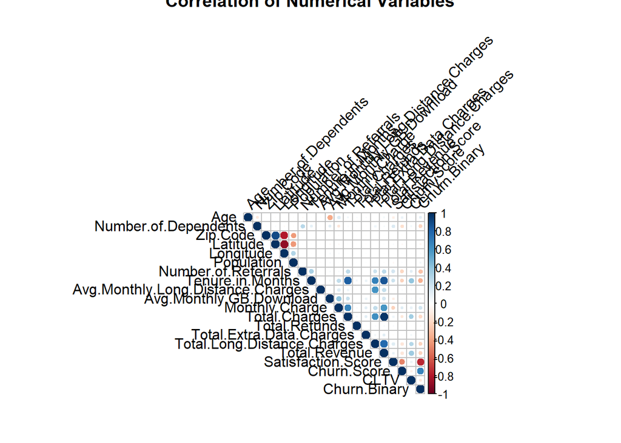

```r
# Correlation analysis for numerical variables
numeric_vars <- select_if(teldata, is.numeric)
correlation_matrix <- cor(numeric_vars, use = "complete.obs")

# Plot correlation matrix
corrplot(correlation_matrix, method = "circle", type = "upper",
         tl.col = "black", tl.srt = 45,
         title = "Correlation of Numerical Variables")
```

### Select one of the methodologies studied in weeks 1-10, and another methodology from weeks 11-15 to apply in the new dataset selected.

Based on the data structure and the problem that I am trying to solve, I am going to use Logistic Regression methodology from week 1-10 and Neural Networks methodology from week 11-15. These methodologies are the most appropriate for this assignment because it will help me find key insights within the dataset.

Prepare data for first model, create a new dataframe by selecting the most important variables, double check missing values, and split data into training and testing sets

```r
model_data <- dplyr::select(teldata, Age, Tenure.in.Months, Monthly.Charge, Total.Charges,
                           Satisfaction.Score, Number.of.Referrals,
                           Avg.Monthly.Long.Distance.Charges, Avg.Monthly.GB.Download,
                           Contract, Internet.Type, Online.Security, Online.Backup,
                           Premium.Tech.Support, Paperless.Billing, Payment.Method,
                           Churn.Binary)


# Check for missing values in model data
missing_values <- colSums(is.na(model_data))
print(missing_values[missing_values > 0])
```

```
## named numeric(0)
```

```r
numeric_cols <- sapply(model_data, is.numeric)
for (col in names(model_data)[numeric_cols]) {
  if (sum(is.na(model_data[[col]])) > 0) {
    model_data[[col]][is.na(model_data[[col]])] <- median(model_data[[col]], na.rm = TRUE)
  }
}

# Split the data into training and testing sets
set.seed(123)
train_indices <- createDataPartition(model_data$Churn.Binary, p = 0.7, list = FALSE)
train_data <- model_data[train_indices, ]
test_data <- model_data[-train_indices, ]
```

Prepare the data for calculations, create functions to extracts all the metric values required for the analysis.

```r
# Define the evaluation metrics function
evaluate_model <- function(actual, predicted, predicted_prob = NULL) {
  # Calculate confusion matrix
  conf_matrix <- confusionMatrix(factor(predicted, levels = c(0, 1)),
                                 factor(actual, levels = c(0, 1)))

  # Extract metrics
  accuracy <- conf_matrix$overall["Accuracy"]
  precision <- conf_matrix$byClass["Pos Pred Value"]
  recall <- conf_matrix$byClass["Sensitivity"]
  f1_score <- conf_matrix$byClass["F1"]

  # Calculate AUC if probabilities are provided
  auc_value <- NA
  if (!is.null(predicted_prob)) {
    roc_obj <- roc(actual, predicted_prob)
    auc_value <- auc(roc_obj)
  }

  # Return the metrics
  return(list(
    Accuracy = accuracy,
    Precision = precision,
    Recall = recall,
    F1_Score = f1_score,
    AUC = auc_value,
    Confusion_Matrix = conf_matrix$table
  ))
}
```

**Logistic Regression Model**

```r
# Create a formula for our logistic model
logistic_formula <- as.formula("Churn.Binary ~ Age + Tenure.in.Months + Monthly.Charge +
                              Satisfaction.Score + Contract + Internet.Type +
                              Online.Security + Premium.Tech.Support")

# Train the logistic regression model
logistic_model <- glm(logistic_formula, data = train_data, family = "binomial")
# Summary of the model
summary(logistic_model)
```

```
##
## Call:
## glm(formula = logistic_formula, family = "binomial", data = train_data)
##
## Coefficients:
##                            Estimate Std. Error z value Pr(>|z|)
## (Intercept)               6.457e+01  1.547e+03   0.042 0.966700
## Age                       1.616e-02  4.702e-03   3.437 0.000588 ***
## Tenure.in.Months         -2.613e-02  4.906e-03  -5.327 1.00e-07 ***
## Monthly.Charge            2.251e-02  7.639e-03   2.947 0.003211 **
## Satisfaction.Score       -2.210e+01  5.156e+02  -0.043 0.965815
## ContractOne Year         -6.487e-01  2.404e-01  -2.699 0.006953 **
## ContractTwo Year         -1.522e+00  3.124e-01  -4.870 1.12e-06 ***
## Internet.TypeDSL         -2.922e-01  3.060e-01  -0.955 0.339558
## Internet.TypeFiber Optic -2.537e-01  3.736e-01  -0.679 0.497030
## Internet.TypeNone        -7.640e-01  3.968e-01  -1.925 0.054200 .
## Online.SecurityYes       -3.487e+00  4.260e-01  -8.184 2.74e-16 ***
## Premium.Tech.SupportYes  -9.427e-01  2.228e-01  -4.231 2.33e-05 ***
## ---
## Signif. codes:  0 '***' 0.001 '**' 0.01 '*' 0.05 '.' 0.1 ' ' 1
##
## (Dispersion parameter for binomial family taken to be 1)
##
##     Null deviance: 5680.4  on 4930  degrees of freedom
## Residual deviance: 1062.0  on 4919  degrees of freedom
## AIC: 1086
##
## Number of Fisher Scoring iterations: 21
```

```r
# Make predictions on test data
logistic_predictions_prob <- predict(logistic_model, test_data, type = "response")
logistic_predictions <- ifelse(logistic_predictions_prob > 0.5, 1, 0)

# Evaluate the logistic regression model
logistic_results <- evaluate_model(test_data$Churn.Binary, logistic_predictions, logistic_predictions_prob)
# Print the results
cat("Logistic Regression Results:\n")
```

```
## Logistic Regression Results:
```

```r
print(logistic_results)
```

```
## $Accuracy
##  Accuracy
## 0.9526515
##
## $Precision
## Pos Pred Value
##      0.9574062
##
## $Recall
## Sensitivity
##   0.9785575
##
## $F1_Score
##        F1
## 0.9678663
##
## $AUC
## Area under the curve: 0.9897
##
## $Confusion_Matrix
##           Reference
## Prediction    0    1
##          0 1506   67
##          1   33  506
```

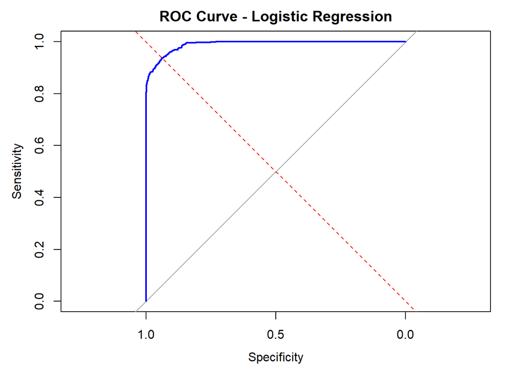

```r
# Plot ROC curve for logistic regression
roc_logistic <- roc(test_data$Churn.Binary, logistic_predictions_prob)
plot(roc_logistic, main = "ROC Curve - Logistic Regression", col = "blue")
abline(a = 0, b = 1, lty = 2, col = "red")
```

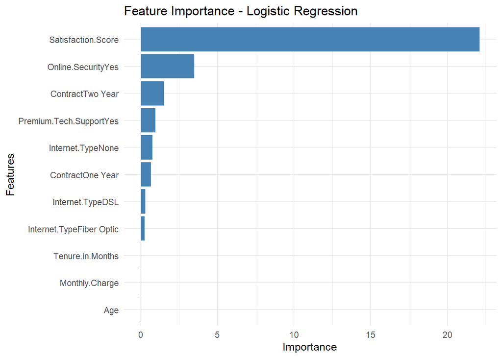

```r
# Calculate variable importance for logistic regression
logistic_importance <- abs(coef(logistic_model)[-1])  # Exclude intercept
logistic_importance_df <- data.frame(
  Feature = names(logistic_importance),
  Importance = as.numeric(logistic_importance)
)
logistic_importance_df <- logistic_importance_df %>% arrange(desc(Importance))

# Plot variable importance
ggplot(logistic_importance_df, aes(x = reorder(Feature, Importance), y = Importance)) +
  geom_bar(stat = "identity", fill = "steelblue") +
  coord_flip() +
  labs(title = "Feature Importance - Logistic Regression", x = "Features", y = "Importance") +
  theme_minimal()
```

The second model that I am going to use from week 11-15 is Neural Network

**Neural Networks**

```r
# Prepare the data for neural network (scaling)
numeric_predictors <- c("Age", "Tenure.in.Months", "Monthly.Charge",
                       "Total.Charges", "Satisfaction.Score", "Number.of.Referrals",
                       "Avg.Monthly.Long.Distance.Charges", "Avg.Monthly.GB.Download")

# Create dataset with only numeric predictors for neural network
train_data_nn <- train_data[, c(numeric_predictors, "Churn.Binary")]
test_data_nn <- test_data[, c(numeric_predictors, "Churn.Binary")]

# Scale numeric features
preproc <- preProcess(train_data_nn[, numeric_predictors], method = c("center", "scale"))
train_data_scaled <- predict(preproc, train_data_nn)
test_data_scaled <- predict(preproc, test_data_nn)

# Create formula for neural network
nn_formula <- as.formula("Churn.Binary ~ Age + Tenure.in.Months + Monthly.Charge +
                        Total.Charges + Satisfaction.Score + Number.of.Referrals +
                        Avg.Monthly.Long.Distance.Charges + Avg.Monthly.GB.Download")

# Train neural network model
set.seed(123)
nn_model <- neuralnet(
  formula = nn_formula,
  data = train_data_scaled,
  hidden = c(5),  # One hidden layer with 5 neurons
  linear.output = FALSE,  # For classification
  threshold = 0.01,
  stepmax = 1e+06,  # Increase the maximum steps for convergence
  rep = 1,  # Number of repetitions
  err.fct = "ce"  # Cross-entropy error function for classification
)
```

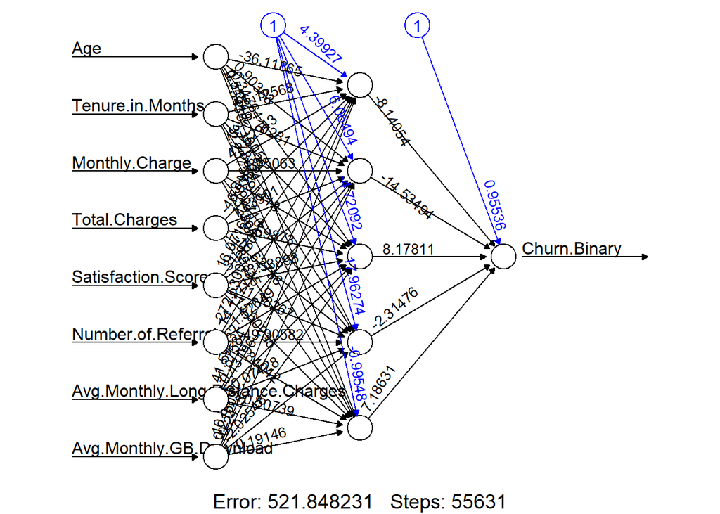

```r
# Plot the neural network
plot(nn_model, rep="best")
```

```r
# Make predictions
nn_output <- compute(nn_model, test_data_scaled[, numeric_predictors])
nn_predictions_prob <- nn_output$net.result
nn_predictions <- ifelse(nn_predictions_prob > 0.5, 1, 0)

# Evaluate the neural network model
nn_results <- evaluate_model(test_data$Churn.Binary, nn_predictions, nn_predictions_prob)
# Print the results
cat("Neural Network Results:\n")
```

```
## Neural Network Results:
```

```r
print(nn_results)
```

```
## $Accuracy
##  Accuracy
## 0.9455492
##
## $Precision
## Pos Pred Value
##       0.946675
##
## $Recall
## Sensitivity
##   0.9805068
##
## $F1_Score
##       F1
## 0.963294
##
## $AUC
## Area under the curve: 0.985
##
## $Confusion_Matrix
##           Reference
## Prediction    0    1
##          0 1509   85
##          1   30  488
```

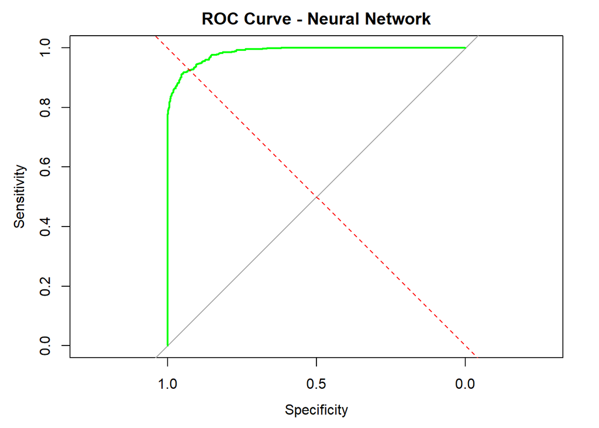

```r
# Plot ROC curve for neural network
roc_nn <- roc(test_data$Churn.Binary, nn_predictions_prob)
plot(roc_nn, main = "ROC Curve - Neural Network", col = "green")
abline(a = 0, b = 1, lty = 2, col = "red")
```

### What’s the purpose of the analysis performed

The purpose of this analysis is to find out the main reasons of customers leaving or stop doing business with the company, find out what are the most relevant factors that might have a high impact on customers, such as competition offering better prices, bad customer service, and demographics.

### Make your conclusions from your analysis. Please be sure to address the business impact (it could be of any domain) of your solution.

First, I am going to compare the two models built to determine which one is the most accurate for this project:

**Model comparison**

```r
# Create a data frame for comparison
model_comparison <- data.frame(
  Model = c("Logistic Regression", "Neural Network"),
  Accuracy = c(logistic_results$Accuracy, nn_results$Accuracy),
  Precision = c(logistic_results$Precision, nn_results$Precision),
  Recall = c(logistic_results$Recall, nn_results$Recall),
  F1_Score = c(logistic_results$F1_Score, nn_results$F1_Score),
  AUC = c(logistic_results$AUC, nn_results$AUC)
)

print(model_comparison)
```

```
##                 Model  Accuracy Precision    Recall  F1_Score       AUC
## 1 Logistic Regression 0.9526515 0.9574062 0.9785575 0.9678663 0.9896785
## 2      Neural Network 0.9455492 0.9466750 0.9805068 0.9632940 0.9850008
```

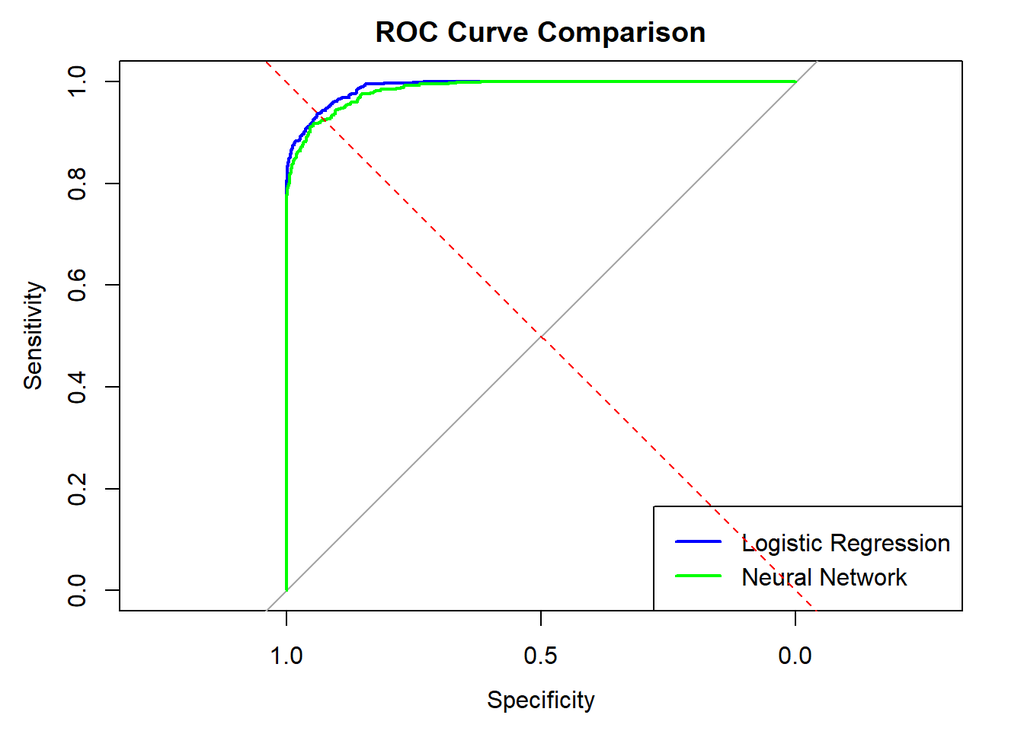

```r
# Plot the ROC curves together for comparison
plot(roc_logistic, col = "blue", main = "ROC Curve Comparison")
lines(roc_nn, col = "green")
legend("bottomright", legend = c("Logistic Regression", "Neural Network"),
       col = c("blue", "green"), lwd = 2)
abline(a = 0, b = 1, lty = 2, col = "red")
```

**Key Insights from Analysis**

After Performing the analysis using both methodologies Logistic Regression and Neural Networks, we can say that there are several factors that have a strong impact on customers when they decided whether they want to stay or leave the company. Here is a list of the most important ones:

**Demographic Factors**

- **Age**: Older customers (seniors) have slightly tendency to stop doing business with the company.
- **Dependents**: Customers without dependents are more likely to stay with the company.

**Satisfaction and Tenure**

- **Satisfaction Score**: Lower satisfaction scores (1-2) strongly correlate with increased churn.
- **Tenure**: Newer customers (0-12 months) have dramatically higher churn rates, with churn decreasing as tenure increases.

I think that the analysis has valuable insights about top reasons that customers tend to stop doing business with the company, based on the results. the top reasons for high churn rates are manageable and it can be corrected to drastically improve the customer’s satisfaction and retention rates, the visualization below shows the top churn reasons and it is vital for the company to address this problems in order to keep the company running:

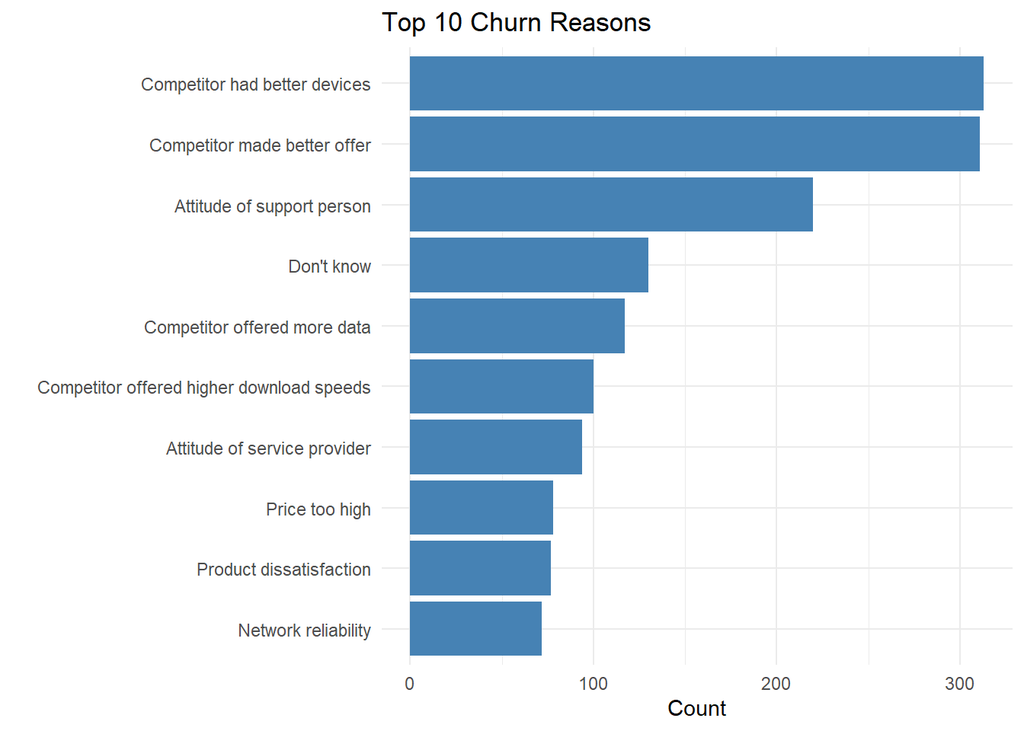

```r
# Explore churn reasons
churn_reasons <- teldata %>%
  filter(Churn.Label == "Yes") %>%
  count(Churn.Reason) %>%
  arrange(desc(n)) %>%
  mutate(percentage = n / sum(n) * 100)

# Visualize top churn reasons
top_reasons <- churn_reasons %>%
  top_n(10, n)

ggplot(top_reasons, aes(x = reorder(Churn.Reason, n), y = n)) +
  geom_bar(stat = "identity", fill = "steelblue") +
  coord_flip() +
  labs(title = "Top 10 Churn Reasons", x = "", y = "Count") +
  theme_minimal()
```

**Recommendations**

Based on the analysis, the company should upgrade the devices that they offer to customers, implement better promotional packages to new customers, review and modify their package prices and internet speed limits, and to improve customer service care.